# 📊 Kompleksowa Analiza EDA i Segmentacja Rynku E-Commerce (Olist)

## 1. Cel i Zakres Projektu

Projekt przedstawia proces end-to-end analizy eksploracyjnej (EDA) brazylijskiego rynku e-commerce na podstawie rzeczywistych, anonimowych danych platformy **Olist** (ok. 100 tys. zamówień z lat 2016–2018).

### 🗺️ Schemat Relacji Bazy Danych (ERD)

Poniższy diagram przedstawia architekturę połączeń i klucze relacyjne pomiędzy tabelami w silniku DuckDB. Pomaga on zrozumieć strukturę bazy przed przystąpieniem do budowania zapytań SQL:

```
erDiagram
    CUSTOMERS {
        varchar customer_id PK
        varchar customer_unique_id
    }
    ORDERS {
        varchar order_id PK
        varchar customer_id FK
        varchar order_status
    }
    ORDER_ITEMS {
        varchar order_id FK
        int order_item_id
        varchar product_id FK
        varchar seller_id FK
        float price
    }
    ORDER_PAYMENTS {
        varchar order_id FK
        int payment_sequential
        varchar payment_type
    }
    ORDER_REVIEWS {
        varchar review_id PK
        varchar order_id FK
        int review_score
    }
    PRODUCTS {
        varchar product_id PK
        varchar product_category_name
    }
    SELLERS {
        varchar seller_id PK
    }
    TRANSLATION {
        varchar product_category_name PK
        varchar product_category_name_english
    }

    CUSTOMERS ||--o{ ORDERS : "customer_id -> customer_id"
    ORDERS ||--|{ ORDER_ITEMS : "order_id -> order_id"
    ORDERS ||--o{ ORDER_PAYMENTS : "order_id -> order_id"
    ORDERS ||--o{ ORDER_REVIEWS : "order_id -> order_id"
    ORDER_ITEMS }|--|| PRODUCTS : "product_id -> product_id"
    ORDER_ITEMS }|--|| SELLERS : "seller_id -> seller_id"
    PRODUCTS }|--o| TRANSLATION : "product_category_name -> product_category_name"
```

## 🛠️ Podejście Technologiczne

W projekcie wykorzystano nowoczesny stos technologiczny: **Python** jako środowisko uruchomieniowe oraz **DuckDB** jako osadzony, wysoce wydajny silnik SQL działający w pamięci (In-Memory). Wszystkie transformacje, czyszczenie oraz agregacje danych zostały wykonane za pomocą **czystego SQL**, co pozwala na błyskawiczne przetwarzanie dużych zbiorów danych bez nadmiernego obciążania pamięci RAM przez tradycyjne biblioteki.

## Krok 1 & 2: Konfiguracja Środowiska, Rejestracja Danych i Testy Integralności

W tej sekcji inicjalizujemy bazę danych oraz mapujemy pliki CSV bezpośrednio jako widoki w DuckDB. Stosujemy regułę **DRY (Don't Repeat Yourself)** przy użyciu pętli słownika. Przeprowadzamy również testy jakości danych (unikalność kluczy głównych oraz brak rekordów osieroconych).

```
✓ Sukces: Wszystkie pliki CSV zostały pomyślnie podpięte jako widoki SQL.

--- 1. WOLUMEN DANYCH W TABELACH ---
Tabela 'customers': 99,441 wierszy
Tabela 'geolocation': 1,000,163 wierszy
Tabela 'order_items': 112,650 wierszy
Tabela 'order_payments': 103,886 wierszy
Tabela 'order_reviews': 99,224 wierszy
Tabela 'orders': 99,441 wierszy
Tabela 'products': 32,951 wierszy
Tabela 'sellers': 3,095 wierszy
Tabela 'translation': 71 wierszy

--- 2. WERYFIKACJA UNIKALNOŚCI KLUCZA GŁÓWNEGO (orders) ---
   total_rows  unique_keys  duplicate_count
0       99441        99441                0

--- 3. TEST INTEGRALNOŚCI REFERENCYJNEJ (Orders -> Customers) ---
Liczba zamówień bez przypisanego klienta (sierot): 0
```

## Krok 3: Czyszczenie Danych i Zaawansowany Feature Engineering

W tym kroku budujemy warstwę danych oczyszczonych (`v_cleaned_*`). Wykorzystujemy rzutowanie typów (`::TIMESTAMP`), mapujemy portugalskie nazwy kategorii na język angielski za pomocą zapytań relacyjnych oraz stosujemy funkcję `COALESCE`, aby bezpiecznie obsłużyć wartości `NULL`. Dodatkowo wprowadzamy dedykowane metryki biznesowe (czas dostawy, flaga opóźnienia).

```
Uruchamianie procesów transformacji danych i budowania widoków analitycznych...
✓ Sukces: Widoki transformacyjne zostały poprawnie utworzone w bazie danych.

--- ANALIZA ZALEŻNOŚCI BRAKU DATY DOSTAWY OD STATUSU ZAMÓWIENIA ---
  order_status  total_orders  missing_delivery_date
0    delivered         96478                      8
1      shipped          1107                   1107
2     canceled           625                    619
3  unavailable           609                    609
4     invoiced           314                    314
5   processing           301                    301
6      created             5                      5
7     approved             2                      2
```

## Krok 4: Analiza Właściwa (EDA) – Hipotezy Biznesowe i Wizualizacje

Przechodzimy do testowania kluczowych hipotez biznesowych. Łączymy wyniki zaawansowanych agregacji SQL bezpośrednio z bibliotekami wizualizacyjnymi (`Seaborn` i `Matplotlib`).

### Hipoteza 1: Trend Przychodów i Wolumenu Zamówień w Czasie

Badamy stabilność wzrostu platformy i identyfikujemy piki sprzedażowe (sezonowość, m.in. Black Friday).

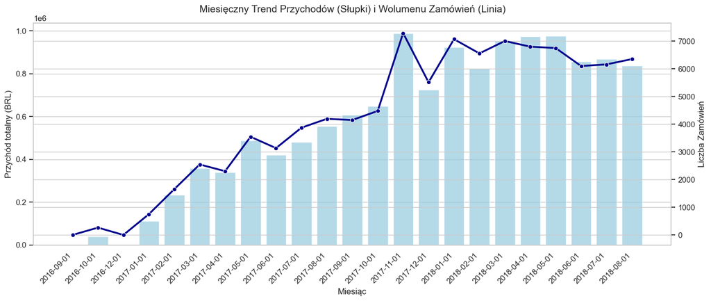

### Hipoteza 2: Analiza Logistyczna i Wąskie Gardła w Dostawach

Weryfikujemy, które stany w Brazylii charakteryzują się najwyższym współczynnikiem opóźnień przesyłek w stosunku do deklarowanej daty estymowanej.

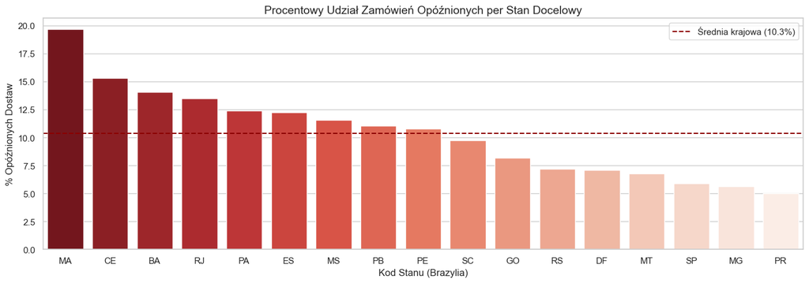

### Hipoteza 3: Wpływ Jakości Logistyki na Satysfakcję Klienta

Sprawdzamy, jak niedotrzymanie obietnicy logistycznej (opóźnienie) wpływa na oceny wystawiane przez klientów w ankietach (`review_score`).

```
--- WPŁYW OPÓŹNIEŃ LOGISTYCZNYCH NA SATYSFAKCJĘ (0 = na czas, 1 = opóźnione) ---
 is_delayed  avg_review_score  total_reviews
          0              4.29          88653
          1              2.57           7708
```

## Krok 5: Zaawansowana Analityka – Segmentacja Klientów RFM

Budujemy kompletny model segmentacyjny oparty o trzy wymiary: Recency, Frequency oraz Monetary. Wykorzystujemy zaawansowane funkcje okna `NTILE()` oraz logikę warunkową `CASE WHEN` bezpośrednio w silniku SQL.

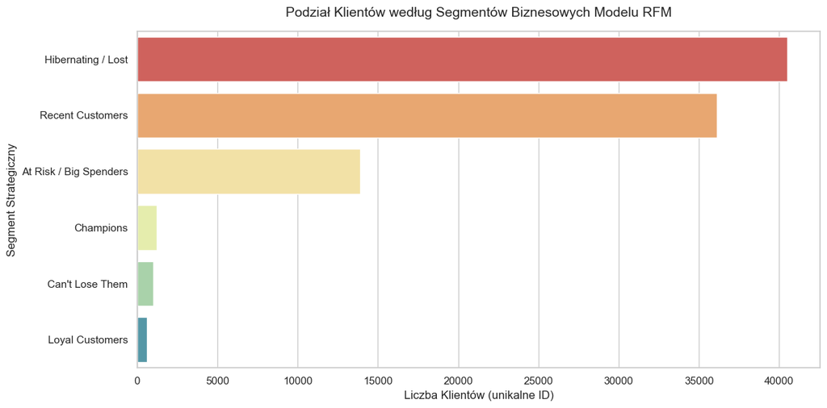